# Reshaping: pivot_longer · pivot_wider

Thursday, June 4, 2026

**NoteToday: Thursday June 4**

**Before class**

- **Perusall Assignment**: [*DC* §12.1](https://psu.instructure.com/courses/2487468/assignments/18325371)

**Plan for today**

- What makes data **tidy**, and why the tidyverse wants it that way
- **Wide** vs. **narrow (long)** layouts of the *same* data
- `pivot_longer()` and `pivot_wider()`
- Choosing a shape to fit the task

**Helpful links**

- Syllabus · AI policy · Schedule · [*R4DS* Ch. 5](https://r4ds.hadley.nz/data-tidy) · [*DC* Ch. 12](https://dtkaplan.github.io/DataComputingEbook/chap-wide-vs-narrow.html#chap:wide-vs-narrow) · [tidyr reference](https://tidyr.tidyverse.org/reference)

## Recap, and what’s new

All week you’ve manipulated data **within** its existing shape, choosing rows, columns, and groups.

**Tip**

`pivot_longer()` and `pivot_wider()` change the **shape** of the table itself, without changing any of the values.

These come from **tidyr**, dplyr’s sibling package (both load with `library(tidyverse)`).

# Tidy data

## What “tidy” means

A dataset is **tidy** when:

1. Each **variable** is a column.
2. Each **observation** is a row.

The same numbers can be stored many different ways. Only one of the following is tidy:

```r
table1   # tidy: country, year, cases, population each a column
```

```
# A tibble: 6 × 4
  country      year  cases population
  <chr>       <dbl>  <dbl>      <dbl>
1 Afghanistan  1999    745   19987071
2 Afghanistan  2000   2666   20595360
3 Brazil       1999  37737  172006362
4 Brazil       2000  80488  174504898
5 China        1999 212258 1272915272
6 China        2000 213766 1280428583
```

## The same data, untidy

```r
table2   # cases and population are stacked into type/count
```

```
# A tibble: 12 × 4
   country      year type            count
   <chr>       <dbl> <chr>           <dbl>
 1 Afghanistan  1999 cases             745
 2 Afghanistan  1999 population   19987071
 3 Afghanistan  2000 cases            2666
 4 Afghanistan  2000 population   20595360
 5 Brazil       1999 cases           37737
 6 Brazil       1999 population  172006362
 7 Brazil       2000 cases           80488
 8 Brazil       2000 population  174504898
 9 China        1999 cases          212258
10 China        1999 population 1272915272
11 China        2000 cases          213766
12 China        2000 population 1280428583
```

`table2` holds identical information, but `type`/`count` jams two variables into a name/value pair. Computing a rate is awkward here and natural in `table1`.

The dead giveaway that the data is **not** tidy here is that there are multiple rows corresponding to the same country / year observation.

**Note**

Why tidy? `dplyr`, `ggplot2`, and friends are built for tidy data. Tidy data is the shape where `mutate()`, `group_by()`, and `aes()` work without needing to change the shape of the data first.

# Wide vs. narrow

## Two layouts of one dataset

Reshaping refers to moving back and forth between **wide** and **narrow** data formats. For example, data on blood pressure (BP) in wide form:

```r
bp_wide <- tribble(
  ~subject, ~before, ~after,
  "BHO",        160,    160,
  "GWB",        115,    135,
  "WJC",        105,    145
)
bp_wide
```

```
# A tibble: 3 × 3
  subject before after
  <chr>    <dbl> <dbl>
1 BHO        160   160
2 GWB        115   135
3 WJC        105   145
```

Here, we have row per **subject**, and `before`/`after` are separate columns.

## The same BP data, narrow

```r
bp_narrow <- bp_wide |>
  pivot_longer(
    cols      = c(before, after),
    names_to  = "when",
    values_to = "sbp"
  )
bp_narrow
```

```
# A tibble: 6 × 3
  subject when     sbp
  <chr>   <chr>  <dbl>
1 BHO     before   160
2 BHO     after    160
3 GWB     before   115
4 GWB     after    135
5 WJC     before   105
6 WJC     after    145
```

Now one row per **measurement occasion** (before/after): the case changed meaning, the numbers didn’t.

**Tip**

Each shape has strengths. *Wide* makes a before/after change a one-line `mutate(change = after - before)`. *Narrow* makes it easy to add more measurement occasions or more variables, and it’s what `ggplot2` usually expects.

# pivot_longer()

## The idea

`pivot_longer()` takes several columns and stacks them into **two** new columns: one holding the old **names**, one holding the old **values**.

There are three arguments after the data:

- `cols`: which columns to gather (compatible with `select()` syntax: `starts_with()`, ranges with `:`, `!`)
- `names_to`: name for the new column that will hold the **old column names**
- `values_to`: name for the new column that will hold the **cell values**

```r
bp_wide |>
  pivot_longer(cols = c(before, after), names_to = "when", values_to = "sbp")
```

**Warning**

Note that `names_to` and `values_to` are **quoted**. They’re names you’re inventing, so they don’t exist in the data yet.

## A real one: when names ARE data

The `billboard` data (in tidyr) has one column **per week** (`wk1`, `wk2`, …). The week is a variable trapped in the column names:

```r
billboard |>
  pivot_longer(
    cols      = starts_with("wk"),
    names_to  = "week",
    values_to = "rank",
    values_drop_na = TRUE
  )
```

```
# A tibble: 5,307 × 5
   artist  track                   date.entered week   rank
   <chr>   <chr>                   <date>       <chr> <dbl>
 1 2 Pac   Baby Don't Cry (Keep... 2000-02-26   wk1      87
 2 2 Pac   Baby Don't Cry (Keep... 2000-02-26   wk2      82
 3 2 Pac   Baby Don't Cry (Keep... 2000-02-26   wk3      72
 4 2 Pac   Baby Don't Cry (Keep... 2000-02-26   wk4      77
 5 2 Pac   Baby Don't Cry (Keep... 2000-02-26   wk5      87
 6 2 Pac   Baby Don't Cry (Keep... 2000-02-26   wk6      94
 7 2 Pac   Baby Don't Cry (Keep... 2000-02-26   wk7      99
 8 2Ge+her The Hardest Part Of ... 2000-09-02   wk1      91
 9 2Ge+her The Hardest Part Of ... 2000-09-02   wk2      87
10 2Ge+her The Hardest Part Of ... 2000-09-02   wk3      92
# ℹ 5,297 more rows
```

`values_drop_na = TRUE` drops the empty weeks (songs that had already fallen off the chart).

## Now it’s plottable

In wide form you *couldn’t* put “week” on an axis, it wasn’t a variable. After pivoting, it is:

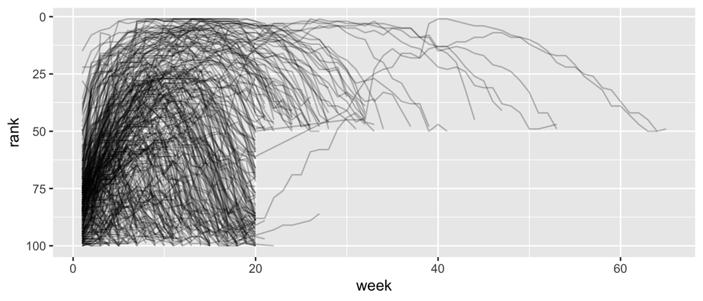

```r
billboard |>
  pivot_longer(
    cols = starts_with("wk"),
    names_to = "week", values_to = "rank",
    values_drop_na = TRUE
  ) |>
  mutate(week = parse_number(week)) |> # "wk3" -> 3
  ggplot(aes(x = week, y = rank, group = track)) +
  geom_line(alpha = 0.25) +
  scale_y_reverse() # rank 1 on top
```

**Note**

This is *why* we pivot: getting a variable out of the column names and into a real column is often the step that makes a plot possible. (`parse_number()` pulls the number out of `"wk3"`.)

# pivot_wider()

## The opposite move

`pivot_wider()` spreads one column’s values across **new columns**. Its two key arguments are the opposite of before:

- `names_from`: the column whose **values become new column names**
- `values_from`: the column whose values **fill the new cells**

```r
bp_narrow |>
  pivot_wider(names_from = when, values_from = sbp)
```

```
# A tibble: 3 × 3
  subject before after
  <chr>    <dbl> <dbl>
1 BHO        160   160
2 GWB        115   135
3 WJC        105   145
```

We’re back to `bp_wide`. **`pivot_longer()` and `pivot_wider()` are inverses.**

## When you might use it

Previously we learned `group_by() |> summarise()` produces a **long** summary. Widening it makes a readable comparison table.

```r
penguins |>
  filter(!is.na(sex)) |>
  group_by(species, sex) |>
  summarise(avg_mass = mean(body_mass_g, na.rm = TRUE), .groups = "drop") |>
  pivot_wider(names_from = sex, values_from = avg_mass)
```

```
# A tibble: 3 × 3
  species   female  male
  <fct>      <dbl> <dbl>
1 Adelie     3369. 4043.
2 Chinstrap  3527. 3939.
3 Gentoo     4680. 5485.
```

## Comparison becomes a mutate operation

With `female` and `male` now side by side in each row, the difference is one `mutate()`:

```r
penguins |>
  filter(!is.na(sex)) |>
  group_by(species, sex) |>
  summarise(avg_mass = mean(body_mass_g, na.rm = TRUE)) |>
  pivot_wider(names_from = sex, values_from = avg_mass) |>
  mutate(diff = male - female)
```

```
# A tibble: 3 × 4
# Groups:   species [3]
  species   female  male  diff
  <fct>      <dbl> <dbl> <dbl>
1 Adelie     3369. 4043.  675.
2 Chinstrap  3527. 3939.  412.
3 Gentoo     4680. 5485.  805.
```

**Tip**

Long form is for **computing and plotting across** a category; wide form is for **reading and comparing within** a row.

# Choosing a shape

## Which way do I pivot?

Match the shape to the next step.

| Your goal | Shape you want | Verb to get there |
| --- | --- | --- |
| Put a “trapped” variable on a plot axis | narrow / long | `pivot_longer()` |
| Group or summarise over a category | narrow / long | `pivot_longer()` |
| Compare two values **per row** (a − b) | wide | `pivot_wider()` |
| A human-readable comparison table | wide | `pivot_wider()` |

**Note**

There isn’t always one “tidy” shape, it depends what you’re doing next. It’s helpful to be comfortable with **untidying, transforming, and re-tidying** as the task changes.

## What we covered today

- **Tidy data:** variables in columns, observations in rows, values in cells
- **Wide vs. narrow:** the same values, different meaning of a “row”
- **`pivot_longer()`:** gather many columns into `names_to` + `values_to`; the fix when a variable is hiding in column names
- **`pivot_wider()`:** spread `names_from` + `values_from` into new columns; the way to a comparison table
- **They’re inverses**, and the right shape is whichever makes your *next* step easiest

# Activity

## Activity: reshaping

Roughly 25 minutes. Individually or with a neighbor.

- [Activity Canvas Link](https://psu.instructure.com/courses/2487468/assignments/)

**Format:** you’ll diagnose whether tables are tidy/wide/narrow, pivot a tiny table by hand-prediction then check, pivot `billboard` longer and plot it, widen a `penguins` summary into a comparison table, confirm the two verbs undo each other, and debug a pivot that went “too narrow.”

**To turn in:** save your `.qmd` and rendered HTML.

## Wrap-up & looking ahead

**Tomorrow (Friday):** **Quiz 3** in the first 20 minutes, then version control, Git and GitHub concepts and a demonstration, so your project team can collaborate on shared code.

**Upcoming Deadlines**

- **Tonight, Thu 6/4, 11:59 p.m.**: [Project: Team formation](https://psu.instructure.com/courses/2487468/assignments/)
- **Fri 6/5, before class**: [*DC* §9.1–9.2](https://psu.instructure.com/courses/2487468/assignments/18325372)
- **Fri 6/5, in class**: Quiz 3
- **Fri 6/5, 11:59 p.m.**: HW 3

**Reach out**

Stuck? Office hours, or email me (cgc5478@psu.edu) or Xinyue (xpw5228@psu.edu).

**Reference**

Syllabus · AI policy · Schedule · [*R4DS* Ch. 5](https://r4ds.hadley.nz/data-tidy) · [*DC* Ch. 12](https://dtkaplan.github.io/DataComputingEbook/chap-wide-vs-narrow.html#chap:wide-vs-narrow) · [tidyr reference](https://tidyr.tidyverse.org/reference)